# Feasibility study on the use of recycling materials for prototyping purposes: a comparative study based on the mechanical resistance

Victor M. López[^1]

Diego Carou[^2]

Fabio A. Cruz S.[^3]

Abstract

3D printing is seen as a disruptive technology, which continues to expand the design space boundaries for prototypes and final products. Sustainability is one of the major objectives for manufacturing and the use of recycled materials becomes a relevant strategy, particularly for improving material resource efficiency. This paper attempts to evaluate the suitability of the substitution of virgin polylactic acid (PLA) by recycled PLA. An experimental plan divided into three phases to evaluate the mechanical resistance was described. The results showed that recycled PLA may be used thanks to the similar resistance, though slightly lower than the virgin material. Besides, the infill density and the orientation parameters played a major role on the response. A retention of the 58.1% of the resistance using an infill density of 40% was evidenced. This is a relevant insight for prescriptions of the 3D printing parameters guaranteeing minimal quality conditions in prototyping.

# Introduction

Fused filament fabrication (FFF) is a major additive manufacturing (also called 3D printing) technology which have found considerable number of applications in different types of manufacturing sectors.<sup>1</sup> The layer-by-layer principle of manufacturing objects enables a higher flexibility degree in the product design phase. The set of several available printing technologies provides advantages such as the customization of objects with complex geometries with a great deal of detail, combination of different materials,<sup>2</sup> reduction of the need for assembly and high utilization rate of raw materials.<sup>3</sup>

Nowadays, there is a need to find paths to reduce the ecological impact of manufacturing processes.<sup>4,5</sup> Researchers are making efforts to identify opportunities of 3D printing on the circular economy paradigm.<sup>6</sup> Moreover, due to the fact that plastic is one of the most used materials in the 3D printing industry,<sup>7</sup> and given their non-biodegradable nature, plastic is one the most abundant type of waste produced and their impact is well document in the different ecosystems.<sup>8</sup> Thus, reducing the consumption of plastics is of great importance.

The major literature coming from engineering, human computer interaction, design thinking or software development<sup>9</sup> validates the rationale for the prototyping phase in the early design phases of product development. According the prototyping theory, different kind of prototypes are needed during the new product development phases (eg. prototype for desirability, feasibility, and viability)<sup>10</sup> with the purpose of reducing uncertainties, exploring new ideas, increasing feasibility and/or engaging with users.<sup>11</sup> Thus, a prototype is accomplished in terms of certain aims: (1) Model to Link, (2) Model to Test, (3) Model to Communicate, (4) Model to Decide, and (5) Model to Interact.<sup>10</sup> Moreover, digital tools allows designers to create highly flexible prototypes that enable short learning cycles at an affordable cost. Indeed, the use of 3D printing technology enables the materialization aspect. Regardless of whether the printed part is functional or not, it is found to be valuable in design decisions.<sup>9</sup> However, there is a gap in the literature in terms of sustainable manufacturing using 3D printing in the early design phases.<sup>5</sup> Although the technology offers high efficiency in the material usage, the democratization of this technology could cause a rebound impact due to the increasing generation and disposal of huge amounts of waste or polluting emissions to fabricate the virgin feedstock required, particularly, in prototyping. Without a doubt, the roots of FFF are linked to the rapid prototyping concept<sup>12</sup> and in the last years it has been widely adopted to create final objects. Therefore, one question that remains is how to define the most favorable printing conditions to create prototypes in the early phases without compromising the mechanical properties, even for recycled feedstocks.

Studies on the technical viability of recycled materials as substitutes for conventional virgin materials are still limited for particular applications.<sup>13</sup> It is important to note that in most cases, prototypes do not require excellent mechanical resistance but the minimum to be handled to allow inspection and measurement. Thus, the type of material used and its amount can be further optimized when it comes to prototyping.

The present study evaluates the mechanical properties of both conventional and recycled polylactic acid (PLA) materials. The objective is the assessment of the suitability of the recycled PLA as replacement in prototyping, though its use may be further extended to other applications. This research is based on a comprehensive experimental study with three main phases in order to evaluate the influence of several printing parameters on the mechanical properties.

# Existing Theories & Previous Work

## Main parameters on Fused Filament Fabrication

The mechanical properties are critical for engineering parts, particularly, for printed parts because of the anisotropy, which can influence up to about 47% the ultimate tensile strength (UTS) in function of the manufacturing parameters.<sup>14</sup> Using a systematic literature review, Popescu et al<sup>15</sup> identified certain key parameters influencing the printed parts including raster-to-raster air gap, raster angle, layer thickness, infill density and build orientation.  
Nevertheless, it is highlighted that it might be uncertain if a set of optimal parameters for a machine/material/application combination can be transferred to other 3D printers due to the issue of intra-3D printer variability. The development of standards to qualify the process is a relevant research path to set minimal requirements for the dimensional accuracy, repeatability and minimum feature size among the 3D printing technologies.<sup>16</sup> Likewise, considering the open source nature of the FFF technology, standardized experimental protocols are relevant to enable benchmarking and serve as a guide for machine selection.<sup>17,18</sup> Therefore, it is crucial to identify the most important parameters that may affect the process quality.<sup>19</sup>

In general terms, it is found that for low values of layer height, the UTS of the material is improved.<sup>20,21</sup> Similarly, Yao et al.<sup>22</sup> identified the importance of the printing orientation in the UTS in which the alignment of the tensile load with the longitudinal axis of the printed fiber will maximize the UTS. According to Alafaghani et al.,<sup>23</sup> a higher extrusion temperature, an optimized layer thickness, a triangular filling pattern and a higher filling level maximize the part strength. By contrary, it is identified that higher printing speed with higher layer thickness leads to lower part strength.

## Materials and distributed recycling

The development of new materials such as polymers, elastomers and composites in engineering plays a fundamental role in the advance of sustainable manufacturing.<sup>24,25</sup> Liu et al.<sup>26</sup> presented a complete review on natural-derived biopolymers for 3D printing purposes, with a particular focus on biomedical, customized food fabrication and textile and apparel products. They suggested the use of biopolymers of natural and renewable origin, replacing synthetic polymers. Polylactic acid (PLA) is a type of natural biopolymer obtained from crops such as starch or sugar cane. It is a biodegradable biopolymer consisting of lactic acid molecules and it is one of the most used materials in 3D printing. In addition, PLA shows a range of crystallinity and mechanical properties between polystyrene and polyethylene terephthalate.<sup>27,28</sup>

In the literature, the distributed recycling via additive manufacturing (DRAM) approach makes an emphasis in the technical steps to reuse plastic waste through the recycling chains for material extrusion based 3D printing.<sup>13,29</sup> The use of recycled material as raw material or blended with virgin material is a method of special interest for sustainable manufacturing.<sup>30</sup> In the DRAM methodology, consumers have an economic incentive to recycle. This is because they can use their waste as feedstock for a wide range of products saving fraction of the conventional cost of the equivalent products. Moreover, 3D printing is especially suited because it allows producing parts with (almost) no waste and could reduce more than 40% of the waste related to the material, reusing 95% of the unused material.<sup>31</sup> Currently, most of the cost of 3D printing is associated with filament.<sup>32</sup> Moreover, by recycling raw materials, the emissions of carbon dioxide can be reduced in the transport to landfills or shipping to customers offering environmental benefits.<sup>33</sup>

It is important to evaluate the properties of the recycled materials before substituting virgin for recycled materials. The use of recycled materials is still uncertain because of the potential changes in the material properties when recycling.<sup>25</sup> Several authors have worked on the PLA recycling for a certain number of cycles.<sup>30,34,35</sup> There is an agreement that PLA adequately withstands two printing cycles since after a third cycle or more the mechanical properties and viscosity decreased considerably. The increase in crystallinity and melting enthalpy and the decrease of the cold crystallization enthalpy are attributed to the 3D printing process, not to the extrusion performed during the extrusion process. Similarly, Kumar et al<sup>27</sup> compared the elongation at break, load at break, flow index, Young’s modulus and breaking stress of recycled ABS, high impact polystyrene (HIPS) and PLA. The PLA showed the highest elongation at break along with the ABS. In addition, the PLA had a higher breaking load and breaking stress, although a smaller Young’s modulus. The recycling of PLA has certain limitations because of reducing the molecular weight with its reuse, resulting in degradation and decrease of mechanical properties.<sup>36</sup> Viscosity is reduced with each printing cycle, but it could be corrected by adding virgin plastic.<sup>28,30</sup> Babagowda et al.<sup>37</sup> studied the influence of the percentage of recycled PLA used in the filament (i.e., 10 to 50 %) showing that the smaller the percentage the higher the ultimate tensile strength. When recycling, there is a decrease in the properties of the material as a result of the presence of carbonyl groups and superficial pitting due to thermomechanical degradation during the new melting process that takes place during 3D printing.<sup>30</sup>

# Experimental procedure

## Materials and equipment

The printing materials tested were commercial virgin and recycled PLA characterized by data listed in Table @ref(tab:tabla1). The recycled PLA contained 10 % of virgin PLA in the blend.

Characterization and processing conditions of the used PLA and recycled PLA

|  | PLA | Recycled PLA |
| --- | --- | --- |
| Composition | PLA (Polylactic resin)- 99% CAS: 9051-89-2 | PLA - 10% CAS: 9051-89-2 and recycled PLA 90% |
| Density | 1.24 g/cm3 | 1.1-1.3 g/cm3 |
| Diameter | 1.75 ± 0.03 mm | 1.75 mm |
| Printing temperature | 220 ± 20 ºC | 205 ± 15 ºC |
| Melting temperature | 180 ºC | 160 ± 10 ºC |

The specimens were printed with a BQ’s Witbox, shown in Figure @ref(fig:machine)a, using the Ultimaker Cura 3.2.1 software. For tensile testing, a MTS Criterion 43 universal testing machine (Figure @ref(fig:machine)b) was used selecting a strain rate of 0.5 mm/min.

The mechanical samples were manufactured according to the dimensions depicted in Figure @ref(fig:machine)c.

[figure not shown]

Equipment used in the study: a) 3D printer, b) Universal testing machine and c) mechanical sample.

## Methodology

The experimental plan included three different phases (Figure @ref(fig:Methodology)) to carry out a comprehensive study with a limited number of tests that do not compromise the reliability of the results.

The main goal of *Phase I* is to identify and discard factors depending on their influence on the response variable. The use of fractional designs is useful for minimizing the number of tests, being used as screening designs. The response variable chosen was the maximum load attained during the testing of the specimen.<sup>27,38</sup> The design included only specimens printed in the horizontal orientation. The use of random order allowed guaranteeing that the hypothesis that the errors are independently distributed random variables was fulfilled.<sup>39</sup> Based on the literature research presented in section @ref(section:background), the critical parameters for the study are the (1) layer height (0.15 and 0.3 mm) and (2) infill pattern (tri-hexagonal and grid). In addition, taking into account the goal of sustainable manufacturing (i.e., optimization of the consumption of material), but also productivity (i.e., minimizing the printing times), (3) infill density (60 and 100%) and (4) printing speed (40 and 80 mm/s) were considered.

Then, the main goal of *Phase II* is to study in more detail the influence of the most influential factor according to the *Phase I*. The intent is to make a focus on how the response variable evolves by varying the most influential factor. For that reason, an extension of the factor levels was established. Similarly, the criteria selection for the other three factors aimed at minimizing the printing time.

Finally, the *Phase III* aimed at evaluating the influence of the anisotropy based on the printing orientation, which may notably affect the mechanical resistance. Because of the anisotropy, the UNE 116005:2012<sup>42</sup> standard requires printing the specimens in three different orientations: edgewise, horizontal and vertical, testing five samples in each orientation. This phase included the printing of 15 specimens of both materials.

[figure not shown]

Summary of the three phases of the experimental plan.

# Findings

## Phase I: Screening phase

Table @ref(tab:phase1) summarizes the experimental strategy with the results of the maximum load attained during this screening phase. A total of 16 samples were tested.

Results of the Phase I

| Material | Layer Height (mm) | Infill Pattern | Infill Density (%) | Printing Speed (mm/s) | Max Load (kN) |
| --- | --- | --- | --- | --- | --- |
| Virgin | 0.15 | Tri-hex | 60 | 40 | 2.21 |
| Virgin | 0.3 | Tri-hex | 60 | 80 | 2.16 |
| Virgin | 0.15 | Grid | 60 | 80 | 2.24 |
| Virgin | 0.3 | Grid | 100 | 80 | 3.60 |
| Virgin | 0.3 | Tri-hex | 100 | 40 | 3.62 |
| Virgin | 0.15 | Tri-hex | 100 | 80 | 3.81 |
| Virgin | 0.15 | Grid | 100 | 40 | 3.79 |
| Virgin | 0.3 | Grid | 60 | 40 | 2.16 |
| Recycled | 0.15 | Tri-hex | 60 | 40 | 2.16 |
| Recycled | 0.3 | Tri-hex | 60 | 80 | 2.16 |
| Recycled | 0.3 | Grid | 60 | 40 | 2.15 |
| Recycled | 0.15 | Tri-hex | 100 | 80 | 3.38 |
| Recycled | 0.3 | Tri-hex | 100 | 40 | 3.37 |
| Recycled | 0.15 | Grid | 60 | 80 | 2.05 |
| Recycled | 0.15 | Grid | 100 | 40 | 3.53 |
| Recycled | 0.3 | Grid | 100 | 80 | 3.49 |

In general, shortly after attaining the maximum load, the fracture of the specimen occurred. However, the nature of the fracture was not homogeneous as shown in Fig @ref(fig:fase1)a. In most cases, the specimens showed a fragile behavior and the fracture, either horizontally or with a lower inclination angle, was clean. However, for the recycled material, the specimens presented a ductile behavior and, properly, the fracture did not occur after the maximum load was attained. In these cases, the tensile tests were cancelled after the maximum load was attained, without reaching a complete fracture. The breakage in these cases occurred at a 45º angle and, in the case of the RE-2 specimen, two parallel fracture lines can be clearly seen. The images of the fractured specimens did not allow us to observe a clear relation of the fracture to the printing conditions. However, the fracture behavior may relate to that explained by Yao et al..<sup>22</sup> The authors identified two different types of fracture: in-layer and interlayer. In general, the interlayer fracture occurs at the interface of two layers when printing in vertical position, even when varying the printing orientation up to 45° from the vertical position. In-layer fracture is more likely when using an edgewise position (or, inclined up to 45° from that position). In this case, the printing direction is the same as the tensile stress direction, which also happens when the horizontal orientation is used. Then, the material layer is not intact after the fracture. As a result, it is likely that both types of fractures coexist in this study, which may explain the heterogeneity of the different fractures.

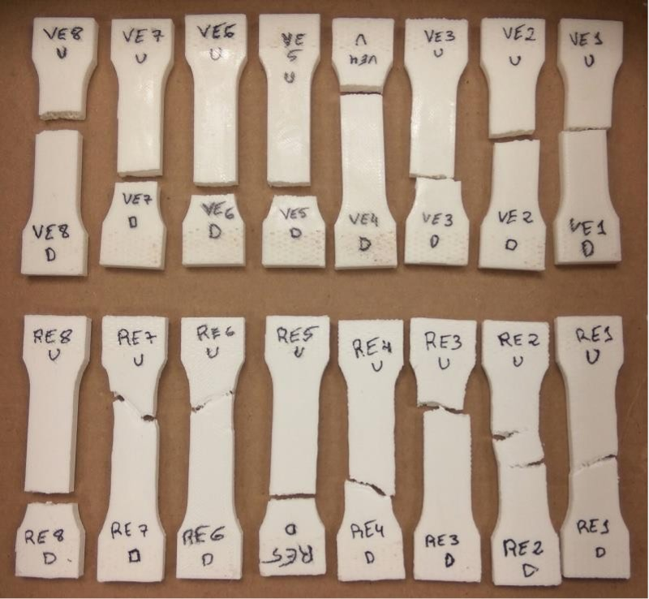

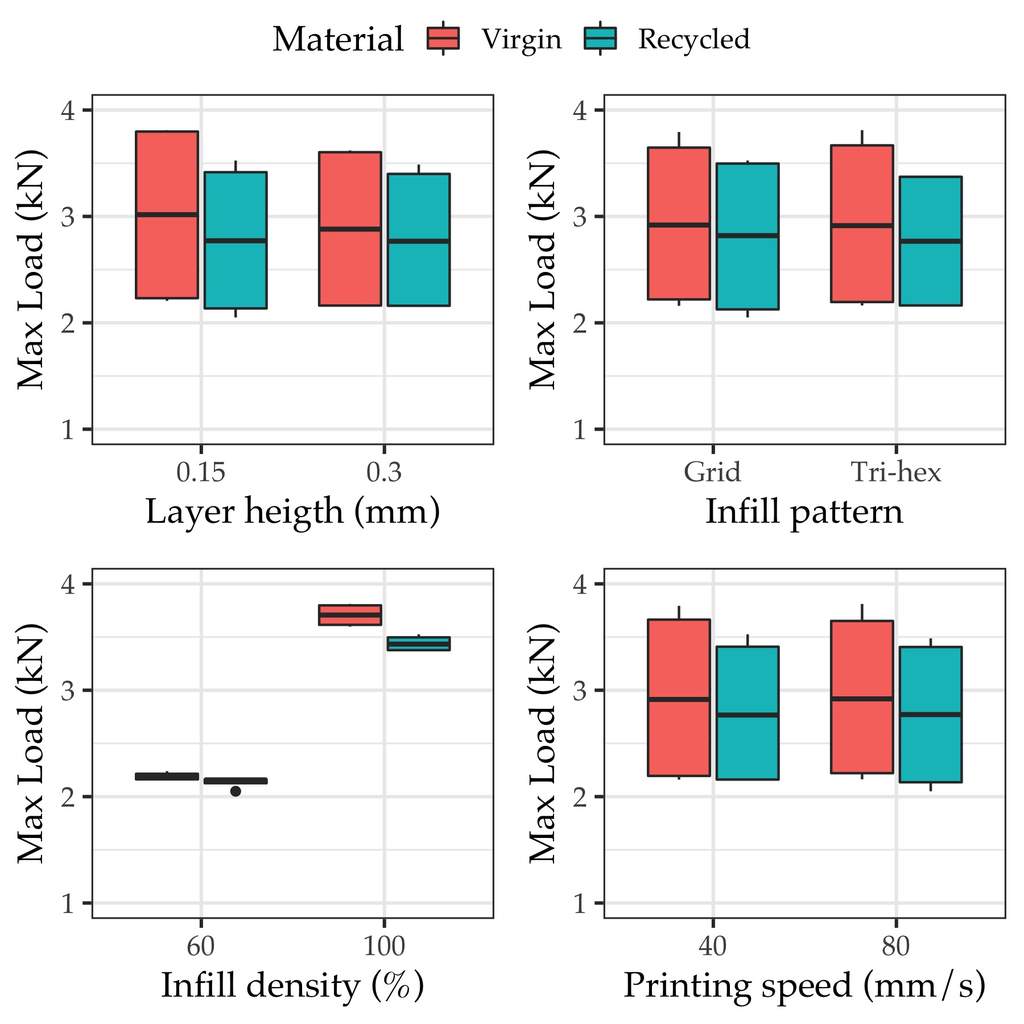

Phase I: screening tests to identify significant factors based on DoE

ANOVA results at 95\% significance level.

| Df | Sum Sq | Mean Sq | F value | Pr(F)* |
| --- | --- | --- | --- | --- |
| 1 | 0.0129 | 0.0129 | 1.34 | 0.274 |
| 1 | 0.00104 | 0.00104 | 0.107 | 0.75 |
| 1 | 7.96 | 7.96 | 825 | 6.1e-11*** |
| 1 | 0.000601 | 0.000601 | 0.0623 | 0.808 |
| 1 | 0.106 | 0.106 | 11 | 0.00788** |
| 10 | 0.0965 | 0.00965 |  |  |

*Signif. codes: 0 ‘***’ 0.001 ‘**’ 0.01 ‘*’ 0.05 ‘.’ 0.1 ‘ ’ 1

An ANOVA was performed using R software in order to identify the influential factors on the response variable.  
As criterion, critical factors for the response variable were those with p-values lower than 0.05.  
Shapiro-Wilk normality tests allowed verifying the normality of the residuals. The figure @ref(fig:fase1)b illustrates the boxplots of the results considering each of the factors. and the Table @ref(tab:anova-phase1) lists the ANOVA. Thus, it can be clearly identified how only the infill density (lowest p-value) and the type of material were statistically significant factors for the maximum load. When evaluating the contribution of each of the factors to the variability explained by the model, there were calculated values of 97.3% and 1.3% for infill density and type of material, respectively. Thus, when manufacturing new parts, infill density is a key factor for guaranteeing adequate mechanical properties.

## Phase II: Focusing

The main goal of *Phase II* is to evaluate in more detail the influence of infill density on the mechanical resistance based on Phase I. Therefore, five levels of the infill density were chosen: 40, 55, 70, 85 and 100%. Regarding the selection of the other printing parameters, the main criteria was the reduction of the printing time. Therefore, the experimental conditions were layer height of 0.3 mm, tri-hexagonal infill pattern and printing speed of 80 mm/s with an estimated printing time of 20 min. A total of 10 samples were manufactured.

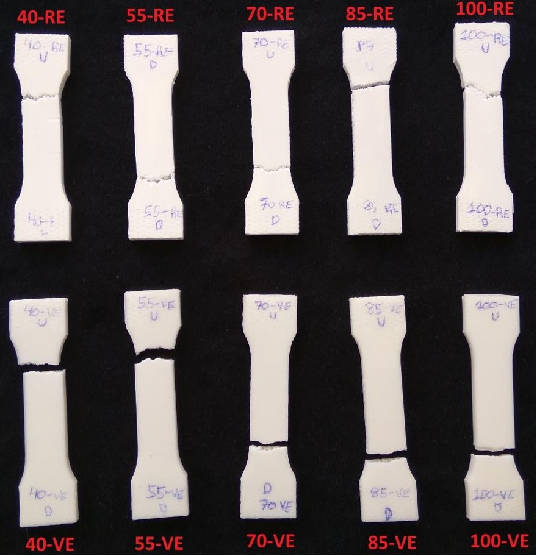

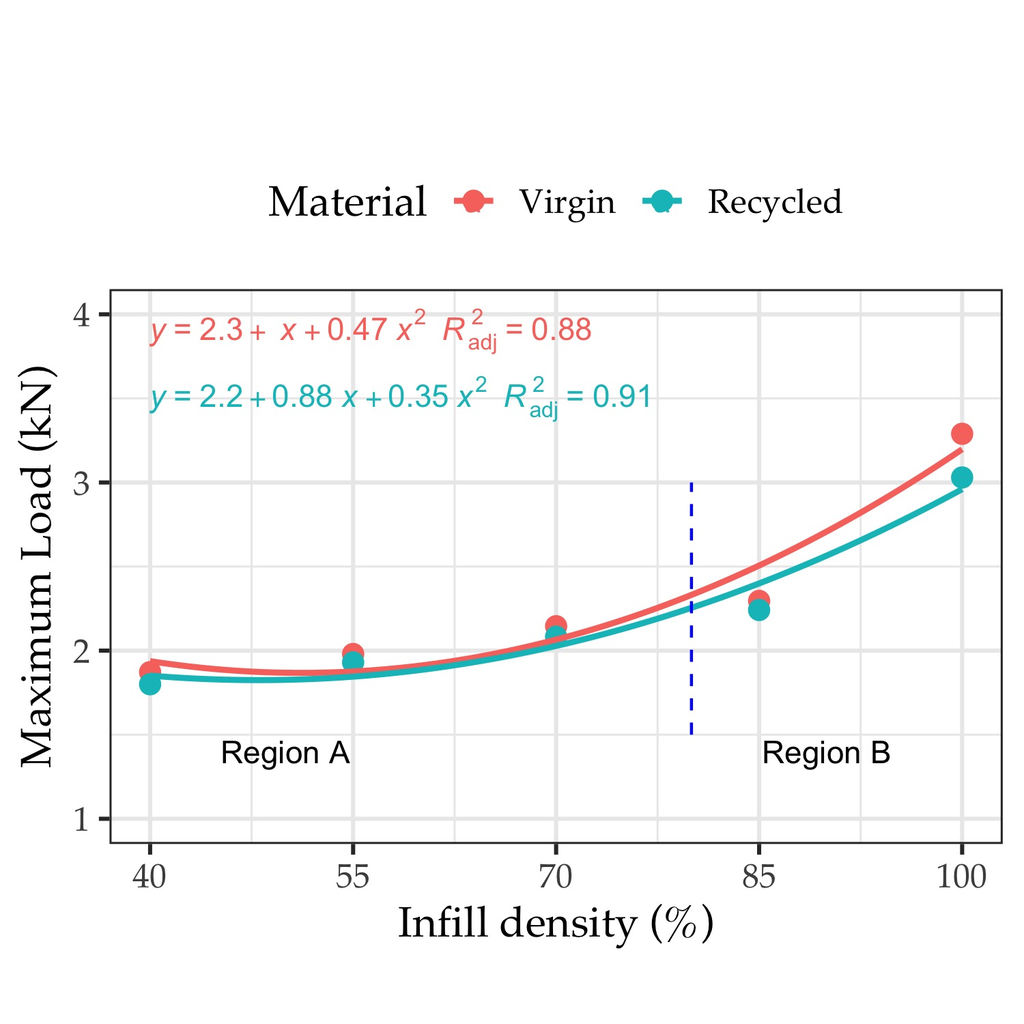

Phase II: Evaluation of the infill density in the mechanical load.

Figure @ref(fig:phase2)a shows the fracture of the specimens tested in *Phase II*. Regarding the fracture, the results were similar to those of the *Phase I* (i.e., more ductile behavior for the recycled PLA specimens). The interesting element in this phase is presented in Figure @ref(fig:phase2)b where the maximum load versus infill density for both materials is illustrated.

From Figure @ref(fig:phase2), it is possible to appreciate that there are two different regions. In the A region, infill densities from 40 to 80 %, the slope of the curve grows slowly with an approximately linear. Moreover, in the B region, from 80 to 100% the increase of the mechanical resistance becomes more pronounced. Regarding the type of material, it is clear that virgin PLA moderately outperforms recycled PLA. These results are in agreement with studies on the comparison of the performance of recycled and virgin PLA<sup>34</sup> in which there was found a difference of about 10% of the mechanical properties in the first recycling cycles. However, the difference notably increased as the infill density approached 100%. The obtained results agree well with those presented by.<sup>43</sup> In their study, the authors studied infill densities of 20, 40, 60, 80 and 100% and the evolution of the tensile strength is similar to the one shown in Figure @ref(fig:phase2).

Based on the results, it appears that an infill density from 100 to 40% implies a relatively limited reduction, in average 41.7%, of the maximum load supported for both types of materials. Although the number of measured points is reduced, it is possible to model the relation between the maximum load versus the infill density for the two tested materials by means of polynomial regressions that are plotted in the figure. The models may help to anticipate the mechanical resistance of a part based on the infill density. Based on the developed models, it is possible to highlight that recycled PLA is a suitable substitute for virgin PLA guaranteeing similar mechanical resistance.

## Phase III: Study on the printing orientation

In this final phase, the main goal is to test the influence of the building orientation according to the UNE 116005:2012<sup>44</sup> standard. Five specimens for each of the orientations (edgewise, horizontal and vertical) for both materials were manufactured. The selected printing conditions were infill density of 50%, printing speed of 80 mm/s, tri-hexagonal infill pattern and layer height of 0.3 mm, with the objective of limiting the use of material and the time required for printing.

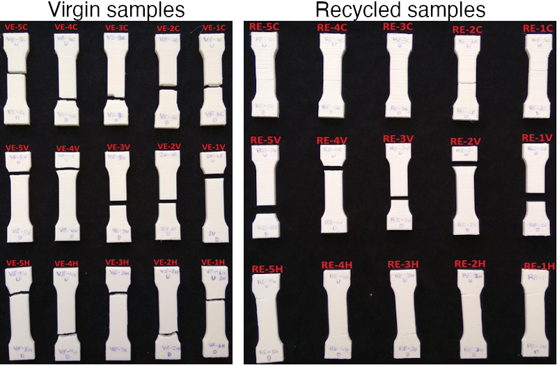

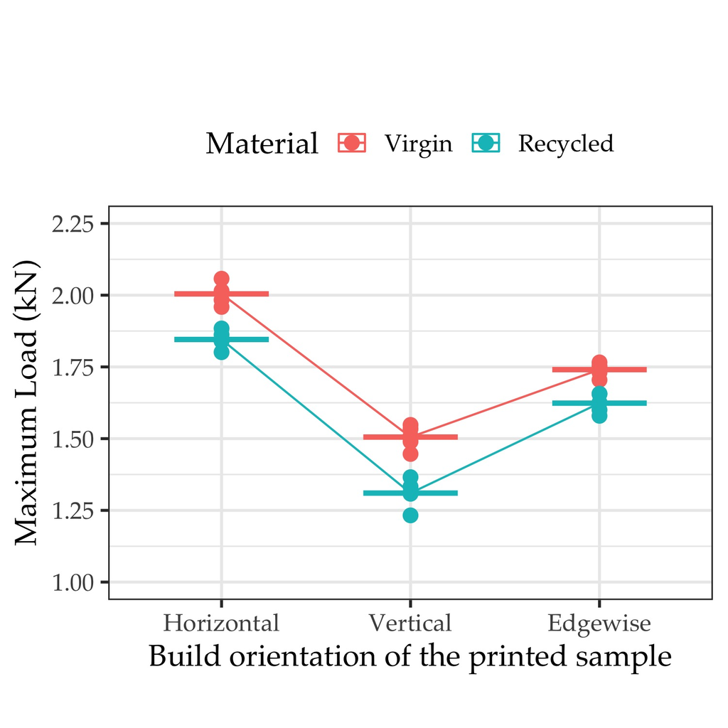

Phase III: Evaluation of the anisotropy.

Figure @ref(fig:phase3)a shows the images of the tested specimens observing the same type of fracture as in the first two phases. It is interesting to evaluate the reduction in the maximum load depending on the type of material and orientation in which the specimens were printed.

The Figure @ref(fig:phase3)b details the maximum load and the mean values for the five specimens at each orientation. From the results, it is clear that the horizontal orientation is the one that provided the higher mechanical resistance, followed by the edgewise orientation. Likewise, the virgin samples performed better than the recycled samples.

The vertical orientation provided the worse results due to the deposition of the layers perpendicular to the tensile direction. These results are in good agreement with those by Corapi et al.<sup>45</sup> and Wang et al..<sup>43</sup> For the recycled material, there is a slight decrease in the maximum load obtained from 6.71 to 13% depending on the orientation with respect to the virgin values. Particularly, the biggest reduction of the load takes place in the vertical orientation with the maximum decrease of 13 %. However, the other two orientations are more adequate for substituting the virgin material with the recycled material with a limited reduction in mechanical resistance (6.71 to 7.93 %).

# Discussion and limits of the results

One of the systemic problems of plastic waste relies on dependency of the indiscriminate disposal of plastics, which carries multiple risks because many plastic products contain additives that modify their physico-mechanical properties, making it difficult the recycling/reuse.<sup>46</sup> The use of 3D printing technology for prototyping is not excepted of this societal issue. The main purpose of this article is to assess to what extent the influence of the printing parameters affects the tensile resistance. While a large literature is focused on the optimization of the parameters for obtaining functional objects using 100% infill density, the approach made here is to observe the influence of a large range of factors considered as critical within conventional printing ranges. This approach enables designers and users to use printing setups that are envisioned for prototypes objects, being secure about the quality of the printed products.

One of the main results in this study relies on that that there is a reduction about 41.7% (in average) of the maximum load supported for PLA (virgin and recycled) when the infill density changes from 100% to 40%. Moreover, it could be inferred from the results that an infill density of 40% retained 58.1% of the mechanical resistance. This is a relevant insight for prescriptions of minimal conditions for 3D printing. Moreover, the use of recycled assets in the printing process may be a relevant path, considering the current priorities of the European Union on circular economy and carbon neutral strategies ambitions.<sup>47</sup> Also, there is a great development of applications using distributed recycling approaches. For instance, Nur-A-Tomal et al<sup>48</sup> presented a valuable example of waste-to-wealth to use waste plastic toys retaining the original colour of waste plastic to fabricate new products. Certainly more research is required to the development of complete closed-loop case studies for prototyping purposes based on material type validating technical, ecological and economic feasibility.<sup>13,49</sup>

There are certain limitations to this work in the perspective of materials and parameters tested. Definitely, the use of other materials is needed to confirm the main findings. Moreover, other factors are needed in order to consider the quality of a prototype in terms of the aesthetic design, dimensional accuracy and surface quality<sup>50</sup> in addition to the mechanical resistance in the prototypes where the main goal is the user acceptability.<sup>51,52</sup> Nevertheless, this is an ongoing research in which the main purpose is the statistical validation of the minimal conditions to promote the use of recycled materials in prototyping.

# Conclusions

The present study includes a comprehensive experimental program to analyze the Fused Filament Fabrication process based on mechanical resistance using virgin PLA and recycled PLA. The paper aims at improving the sustainability of the 3D printing process, assessing the technical feasibility of the substitution of virgin with recycled filaments.

The printing conditions determined in a great manner the mechanical resistance of the specimens. Specifically, the most influential factor on the maximum load was the infill density.  
The influence of the infill density on the maximum load allowed identifying two different regions: from 40 to 80%, linear behavior with a slight slope, and from 80 to 100 % where the maximum load increases to a greater extent. In general, the fracture of the virgin material corresponded to a fragile material, while the fracture of the recycled material showed a more ductile behavior.

# Acknowledgements

The authors thank TEP 250 research group and to the Lorraine Fab Living Lab. This research has received funding from the European Union’s Horizon 2020 research and innovation programme under grant agreement No 869952.

# Declaration of interest statement

The authors report no declarations of interest.

# References

1.

Singh S, Singh G, Prakash C, et al. Current status and future directions of fused filament fabrication. 2020; 55: 288–306.

2.

Askari M, Hutchins DA, Thomas PJ, et al. Additive manufacturing of metamaterials: A review. *Addit Manuf* 2020; 36: 101562.

3.

Wang L, Jiang S, Zhang S. Mapping technological trajectories and exploring knowledge sources: A case study of 3D printing technologies. *Technol Forecast Soc Change* 2020; 161: 120251.

4.

Niaki MK, Torabi SA, Nonino F. Why manufacturers adopt additive manufacturing technologies: The role of sustainability. *J Clean Prod* 2019; 222: 381–392.

5.

Peng T, Kellens K, Tang R, et al. Sustainability of additive manufacturing: An overview on its energy demand and environmental impact. *Addit Manuf* 2018; 21: 694–704.

6.

Despeisse M, Baumers M, Brown P, et al. Unlocking value for a circular economy through 3D printing: A research agenda. *Technol Forecast Soc Change* 2017; 115: 75–84.

7.

González-Henríquez CM, Sarabia-Vallejos MA, Rodriguez-Hernandez J. Polymers for additive manufacturing and 4D-printing: Materials, methodologies, and biomedical applications. *Prog Polym Sci* 2019; 94: 57–116.

8.

Ryberg MW, Hauschild MZ, Wang F, et al. Global environmental losses of plastics across their value chains. *Resour Conserv Recycl* 2019; 151: 104459.

9.

Elverum CW, Welo T, Tronvoll S. Prototyping in New Product Development: Strategy Considerations. *Procedia CIRP* 2016; 50: 117–122.

10.

Menold J, Jablokow K, Simpson T. Prototype for X (PFX): A holistic framework for structuring prototyping methods to support engineering design. *Des Stud* 2017; 50: 70–112.

11.

Hansen CA, Özkil AG. From Idea to Production: A Retrospective and Longitudinal Case Study of Prototypes and Prototyping Strategies. *J Mech Des*; 142. Epub ahead of print March 2020. DOI: 10.1115/1.4045385.

12.

Campbell I, Bourell D, Gibson I. Additive manufacturing: rapid prototyping comes of age. *Rapid Prototyp J* 2012; 18: 255–258.

13.

Cruz Sanchez FA, Boudaoud H, Camargo M, et al. Plastic recycling in additive manufacturing: A systematic literature review and opportunities for the circular economy. *J Clean Prod* 2020; 264: 121602.

14.

Laureto JJ, Pearce JM. Anisotropic mechanical property variance between ASTM D638-14 type i and type iv fused filament fabricated specimens. *Polym Test* 2018; 68: 294–301.

15.

Popescu D, Zapciu A, Amza C, et al. FDM process parameters influence over the mechanical properties of polymer specimens: A review. *Polym Test* 2018; 69: 157–166.

16.

Rebaioli L, Fassi I. A review on benchmark artifacts for evaluating the geometrical performance of additive manufacturing processes. *Int J Adv Manuf Technol* 2017; 93: 2571–2598.

17.

Cruz Sanchez FA, Boudaoud H, Muller L, et al. Towards a standard experimental protocol for open source additive manufacturing. *Virtual Phys Prototyp* 2014; 9: 151–167.

18.

Roberson Da, Espalin D, Wicker RB. 3D printer selection: A decision-making evaluation and ranking model. *Virtual Phys Prototyp* 2013; 8: 201–212.

19.

Jaisingh Sheoran A, Kumar H. Fused Deposition modeling process parameters optimization and effect on mechanical properties and part quality: Review and reflection on present research. In: *Mater. Today proc.*, pp. 1659–1672.

20.

Tymrak BM, Kreiger M, Pearce JM. Mechanical properties of components fabricated with open-source 3-D printers under realistic environmental conditions. *Mater Des* 2014; 58: 242–246.

21.

Altan M, Eryildiz M, Gumus B, et al. Effects of process parameters on the quality of PLA products fabricated by fused deposition modeling (FDM): Surface roughness and tensile strength. *Mater Test* 2018; 60: 471–477.

22.

Yao T, Deng Z, Zhang K, et al. A method to predict the ultimate tensile strength of 3D printing polylactic acid (PLA) materials with different printing orientations. *Compos Part B Eng* 2019; 163: 393–402.

23.

Alafaghani A aldin, Qattawi A. Investigating the effect of fused deposition modeling processing parameters using Taguchi design of experiment method. *J Manuf Process* 2018; 36: 164–174.

24.

Ashby MF, Johnson K. *Materials and design: the art and science of material selection in product design*. Butterworth-Heinemann, 2013.

25.

Suárez L, Domínguez M. Sustainability and environmental impact of fused deposition modelling (FDM) technologies. *Int J Adv Manuf Technol* 2020; 106: 1267–1279.

26.

Liu J, Sun L, Xu W, et al. Current advances and future perspectives of 3D printing natural-derived biopolymers. *Carbohydr Polym* 2019; 207: 297–316.

27.

Kumar R, Singh R, Farina I. On the 3D printing of recycled ABS, PLA and HIPS thermoplastics for structural applications. *PSU Res Rev* 2018; 2: 115–137.

28.

Zhao XG, Hwang K-J, Lee D, et al. Enhanced mechanical properties of self-polymerized polydopamine-coated recycled PLA filament used in 3D printing. *Appl Surf Sci* 2018; 441: 381–387.

29.

Little HA, Tanikella NG, J. Reich M, et al. Towards Distributed Recycling with Additive Manufacturing of PET Flake Feedstocks. *Materials (Basel)* 2020; 13: 4273.

30.

Zhao P, Rao C, Gu F, et al. Close-looped recycling of polylactic acid used in 3D printing: An experimental investigation and life cycle assessment. *J Clean Prod* 2018; 197: 1046–1055.

31.

Petrovic V, Vicente Haro Gonzalez J, Jordá Ferrando O, et al. Additive layered manufacturing: sectors of industrial application shown through case studies. *Int J Prod Res* 2011; 49: 1061–1079.

32.

Wittbrodt BT, Glover AG, Laureto J, et al. Life-cycle economic analysis of distributed manufacturing with open-source 3-D printers. *Mechatronics* 2013; 23: 713–726.

33.

Santander P, Cruz Sanchez FA, Boudaoud H, et al. Closed loop supply chain network for local and distributed plastic recycling for 3D printing: a MILP-based optimization approach. *Resour Conserv Recycl* 2020; 154: 104531.

34.

Cruz Sanchez FA, Boudaoud H, Hoppe S, et al. Polymer recycling in an open-source additive manufacturing context: Mechanical issues. *Addit Manuf* 2017; 17: 87–105.

35.

Lanzotti A, Martorelli M, Maietta S, et al. A comparison between mechanical properties of specimens 3D printed with virgin and recycled PLA. *Procedia CIRP* 2019; 79: 143–146.

36.

Pinho AC, Amaro AM, Piedade AP. 3D printing goes greener: Study of the properties of post-consumer recycled polymers for the manufacturing of engineering components. *Waste Manag* 2020; 118: 426–434.

37.

Babagowda, Kadadevara Math RS, Goutham R, et al. Study of Effects on Mechanical Properties of PLA Filament which is blended with Recycled PLA Materials. *IOP Conf Ser Mater Sci Eng* 2018; 310: 012103.

38.

Chacón JM, Caminero MA, García-Plaza E, et al. Additive manufacturing of PLA structures using fused deposition modelling: Effect of process parameters on mechanical properties and their optimal selection. *Mater Des* 2017; 124: 143–157.

39.

Montgomery DC. *Design and Analysis of Experiments*. John Wiley; Sons Inc, 2001.

40.

Singh R, Singh H, Farina I, et al. On the additive manufacturing of an energy storage device from recycled material. *Compos Part B Eng* 2019; 156: 259–265.

41.

Tanveer MdQ, Haleem A, Suhaib M. Effect of variable infill density on mechanical behaviour of 3-D printed PLA specimen: an experimental investigation. *SN Appl Sci* 2019; 1: 1–12.

42.

UNE. UNE 116005:2012 Fabricación por adición de capas en materiales...

43.

Wang S, Ma Y, Deng Z, et al. Effects of fused deposition modeling process parameters on tensile, dynamic mechanical properties of 3D printed polylactic acid materials. *Polym Test* 2020; 86: 106483.

44.

García-Domínguez A, Claver J, Camacho AM, et al. Considerations on the Applicability of Test Methods for Mechanical Characterization of Materials Manufactured by FDM. *Materials (Basel)* 2019; 13: 28.

45.

Corapi D, Morettini G, Pascoletti G, et al. Characterization of a polylactic acid (PLA) produced by Fused Deposition Modeling (FDM) technology. In: *Procedia struct. integr.* Elsevier B.V., 2019, pp. 289–295.

46.

Wagner S, Schlummer M. Legacy additives in a circular economy of plastics: Current dilemma, policy analysis, and emerging countermeasures. 2020; 158: 104800.

47.

Schwarz AE, Ligthart TN, Godoi Bizarro D, et al. Plastic recycling in a circular economy; determining environmental performance through an LCA matrix model approach. *Waste Manag* 2021; 121: 331–342.

48.

Nur-A-Tomal MS, Pahlevani F, Sahajwalla V. Direct transformation of waste children’s toys to high quality products using 3D printing: A waste-to-wealth and sustainable approach. *J Clean Prod*; 267. Epub ahead of print 2020. DOI: 10.1016/j.jclepro.2020.122188.

49.

Sauerwein M, Doubrovski E, Balkenende R, et al. Exploring the potential of additive manufacturing for product design in a circular economy. *J Clean Prod* 2019; 226: 1138–1149.

50.

Jin Y, Wan Y, Zhang B, et al. Modeling of the chemical finishing process for polylactic acid parts in fused deposition modeling and investigation of its tensile properties. *J Mater Process Technol* 2017; 240: 233–239.

51.

Sauer J, Sonderegger A. The influence of prototype fidelity and aesthetics of design in usability tests: Effects on user behaviour, subjective evaluation and emotion. *Appl Ergon* 2009; 40: 670–677.

52.

Sauer J, Seibel K, Rüttinger B. The influence of user expertise and prototype fidelity in usability tests. *Appl Ergon* 2010; 41: 130–140.

[^1]: University of Jaén, Department of Mechanical and Mining Engineering, 23071 Jaén, Spain
[^2]: Universidade de Vigo, Departamento de Deseño na Enxeñaría, Ourense, Spain , diecapor@uvigo.es
[^3]: Université de Lorraine - ERPI - F-54000, Nancy, France, cruzsanc1@univ-lorraine.fr